# Разведочный анализ данных

Evgenii Berdinskikh

2024-12-07

# Загрузка Tidy data для анализа

```r
brain_data <- read_csv("../data/raw/brain_data.csv", show_col_types = FALSE) %>%
  mutate( across( starts_with("Sud"), ~ as.factor(.) ) )

skim(brain_data)
```

Data summary

| Name | brain_data |
| --- | --- |
| Number of rows | 5737 |
| Number of columns | 16 |
| _______________________ |  |
| Column type frequency: |  |
| Date | 1 |
| factor | 2 |
| numeric | 13 |
| ________________________ |  |
| Group variables | None |

**Variable type: Date**

| skim_variable | n_missing | complete_rate | min | max | median | n_unique |
| --- | --- | --- | --- | --- | --- | --- |
| Date | 0 | 1 | 2006-11-30 | 2022-08-14 | 2014-10-07 | 5737 |

**Variable type: factor**

| skim_variable | n_missing | complete_rate | ordered | n_unique | top_counts |
| --- | --- | --- | --- | --- | --- |
| Sud_Imp | 0 | 1 | FALSE | 2 | No: 5667, Yes: 70 |
| Sud_Storm | 0 | 1 | FALSE | 2 | No: 5611, Yes: 126 |

**Variable type: numeric**

| skim_variable | n_missing | complete_rate | mean | sd | p0 | p25 | p50 | p75 | p100 | hist |
| --- | --- | --- | --- | --- | --- | --- | --- | --- | --- | --- |
| EMS | 0 | 1.00 | 12.57 | 6.23 | 0.0 | 8.0 | 12.0 | 17.00 | 40.0 | ▅▇▅▁▁ |
| F10.7 | 0 | 1.00 | 92.61 | 28.42 | 63.4 | 70.4 | 79.5 | 109.10 | 255.0 | ▇▂▁▁▁ |
| Wind | 0 | 1.00 | 3.10 | 1.43 | 0.0 | 2.0 | 3.0 | 4.00 | 12.0 | ▇▇▂▁▁ |
| Pressure | 914 | 0.84 | 722.06 | 7.04 | 703.8 | 716.8 | 721.3 | 726.85 | 748.4 | ▁▇▆▂▁ |
| Temp_mean | 0 | 1.00 | 1.69 | 13.72 | -34.2 | -9.8 | 3.5 | 13.90 | 25.8 | ▁▆▆▇▇ |
| Temp_min | 0 | 1.00 | -3.33 | 13.14 | -38.6 | -14.0 | -1.3 | 8.00 | 20.4 | ▁▅▆▇▆ |
| Temp_max | 0 | 1.00 | 7.91 | 14.65 | -30.4 | -4.7 | 9.3 | 21.10 | 35.6 | ▁▆▆▇▆ |
| H2O | 0 | 1.00 | 1.28 | 4.33 | 0.0 | 0.0 | 0.0 | 0.70 | 80.1 | ▇▁▁▁▁ |
| Sunspots | 0 | 1.00 | 41.31 | 44.75 | 0.0 | 0.0 | 25.0 | 68.00 | 220.0 | ▇▂▂▁▁ |
| Ap_mean | 0 | 1.00 | 7.75 | 7.86 | 0.0 | 3.0 | 5.0 | 10.00 | 108.0 | ▇▁▁▁▁ |
| Dst_mean | 0 | 1.00 | -9.90 | 13.28 | -127.0 | -16.0 | -8.0 | -1.00 | 21.0 | ▁▁▁▆▇ |
| Dst_min | 0 | 1.00 | -20.59 | 18.53 | -234.0 | -27.0 | -16.0 | -9.00 | 11.0 | ▁▁▁▁▇ |
| Dst_max | 0 | 1.00 | 0.40 | 12.49 | -82.0 | -6.0 | 1.0 | 8.00 | 77.0 | ▁▁▇▁▁ |

# Корреляция количественных переменных

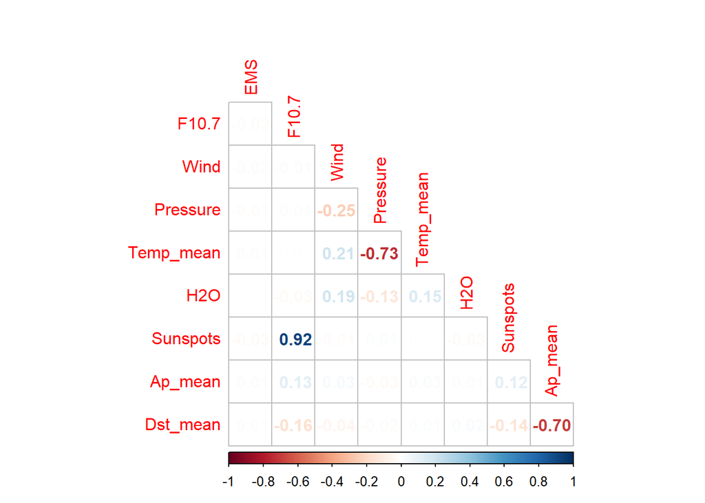

```r
cor_data <- brain_data %>%
  select( where(is.numeric) & !c(ends_with("min"), ends_with("max")) ) %>%
  cor(use = "pairwise.complete.obs")

corrplot(cor_data, method = 'number', type = 'lower', diag = FALSE)
```

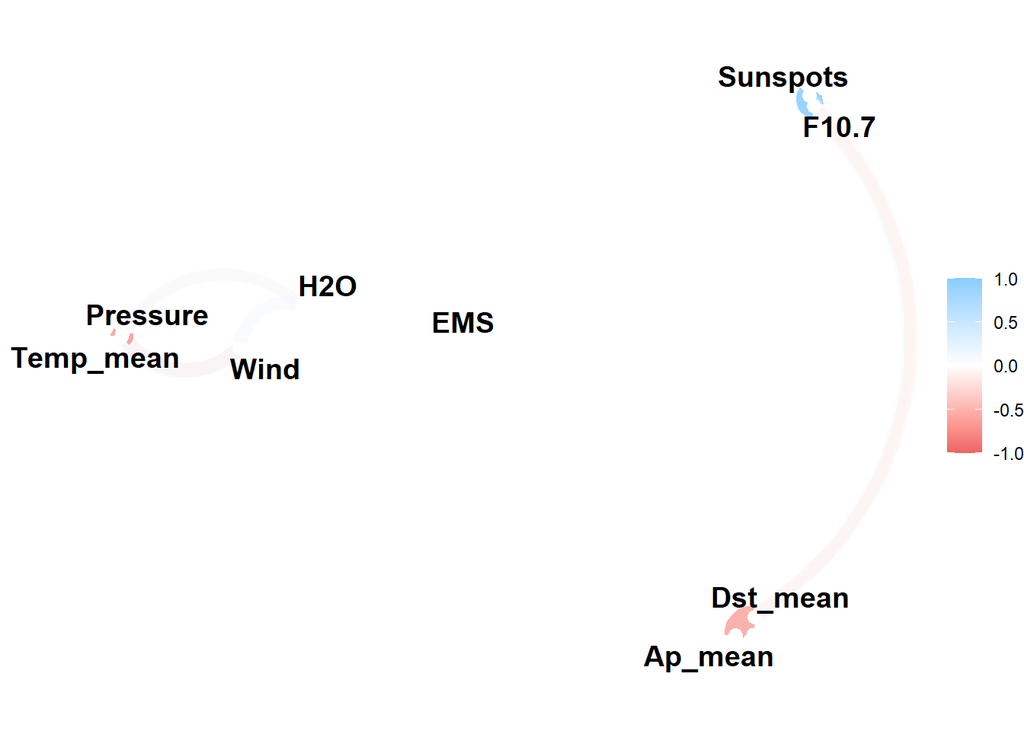

```r
network_plot(cor_data, min_cor = .1)
```

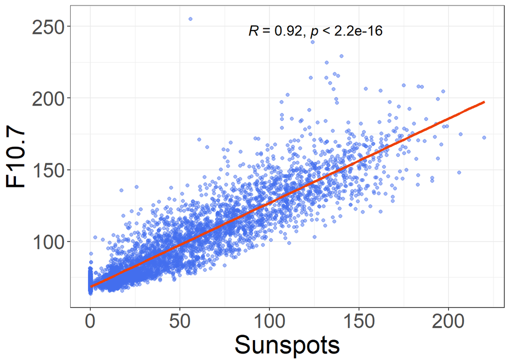

```r
brain_data %>%
  ggplot(aes(Sunspots, F10.7))+
  geom_jitter(alpha = 0.5, colour = "royalblue2", size = 1.5)+
  geom_smooth(method = "lm", se = FALSE, colour = "orangered2", linewidth = 1.2) +
  stat_cor(method = "pearson", label.x.npc = 0.4, label.y.npc = "top", size = 5)+
  theme_custom
```

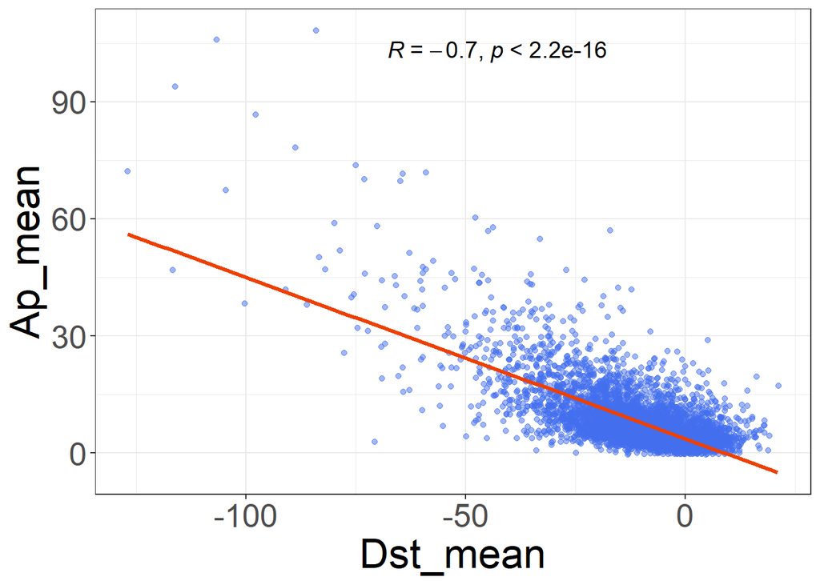

```r
brain_data %>%
  ggplot(aes(Dst_mean, Ap_mean))+
  geom_jitter(alpha = 0.5, colour = "royalblue2", size = 1.5)+
  geom_smooth(method = "lm", se = FALSE, colour = "orangered2", linewidth = 1.2) +
  stat_cor(method = "pearson", label.x.npc = 0.4, label.y.npc = "top", size = 5)+
  theme_custom
```

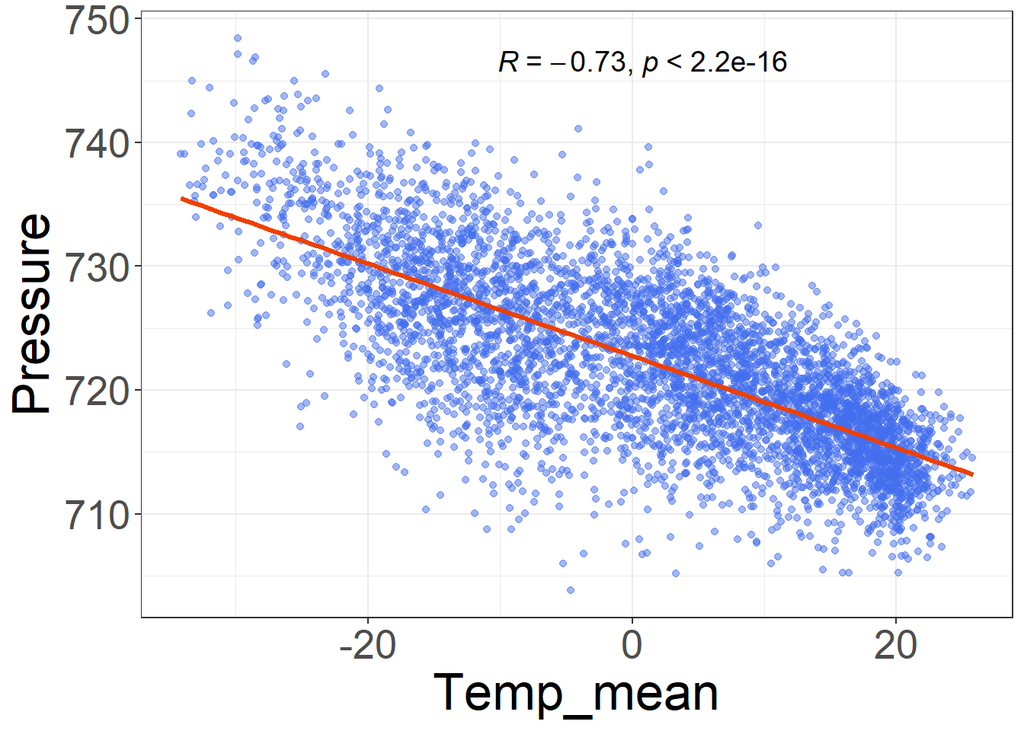

```r
brain_data %>%
  drop_na() %>%
  ggplot(aes(Temp_mean, Pressure))+
  geom_jitter(alpha = 0.5, colour = "royalblue2", size = 1.5)+
  geom_smooth(method = "lm", se = FALSE, colour = "orangered2", linewidth = 1.2) +
  stat_cor(method = "pearson", label.x.npc = 0.4, label.y.npc = "top", size = 5)+
  theme_custom
```

- Индекс **F10.7** и количество **солнечных пятен** показывают высокую корреляцию (r = 0.92), поскольку оба показателя отражают солнечную активность, но измеряются разными методами.
- Среднесуточные индексы **Ap** и **Dst** также заметно коррелируют (r = -0.70), так как оба характеризуют изменения в геомагнитном поле Земли под воздействием солнечного ветра.
- Также ожидаемо выявлена отрицательная корреляция между средней температурой и давлением за день (r = -0.73).

Для дальнейшего анализа из каждой пары переменных оставим одну:  
1. **Количество солнечных пятен** — этот показатель имеет полный набор данных и обладает большей вариативностью.  
2. **Индекс Dst** — напрямую связан с влиянием солнечной активности на магнитосферу.  
3. **Температура** — обеспечивает полный охват данных за весь период исследования и обладает более высокой вариативностью.

# Циклы солнечной активности

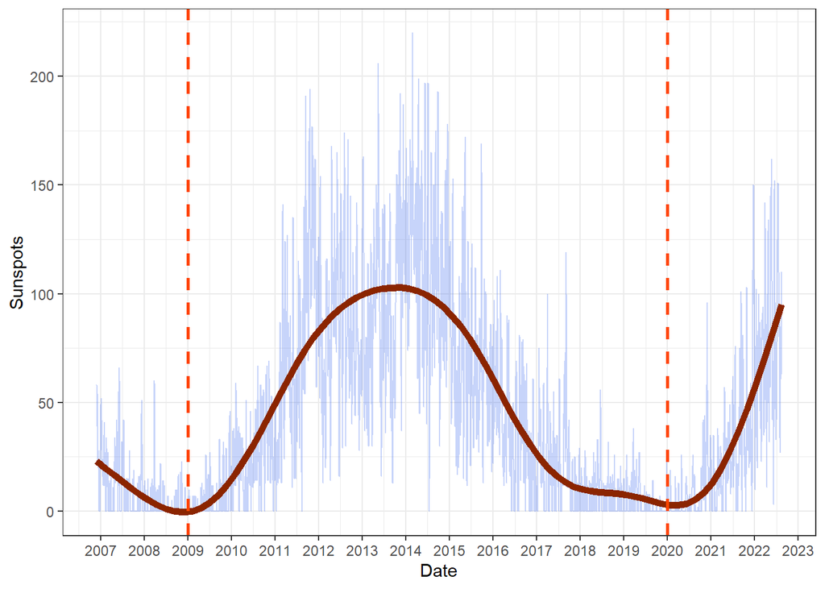

```r
brain_data %>%
  select(!c(Pressure, F10.7, Ap_mean)) %>%
  ggplot(aes(Date, Sunspots))+
  geom_line(alpha = 0.3, colour = "royalblue2")+
  geom_smooth(method = "gam", formula = y ~ s(x, k = 10),  se = FALSE,
              colour = "orangered4", linewidth = 2) +
  geom_vline(xintercept = as.Date("2009-01-01"),
             colour = "orangered", linewidth = 1, linetype = "dashed")+
  geom_vline(xintercept = as.Date("2019-12-31"),
             colour = "orangered", linewidth = 1, linetype = "dashed")+
  scale_x_date(date_breaks = "1 year", date_labels = "%Y")+
  theme_bw()
```

Количество солнечных пятен тесно связано с циклами солнечной активности, что подтверждено на графике. Для дальнейшего анализа выбран период 2009-2019гг., который полностью охватывает 24-й цикл солнечной активности.

# Декомпозиция данных

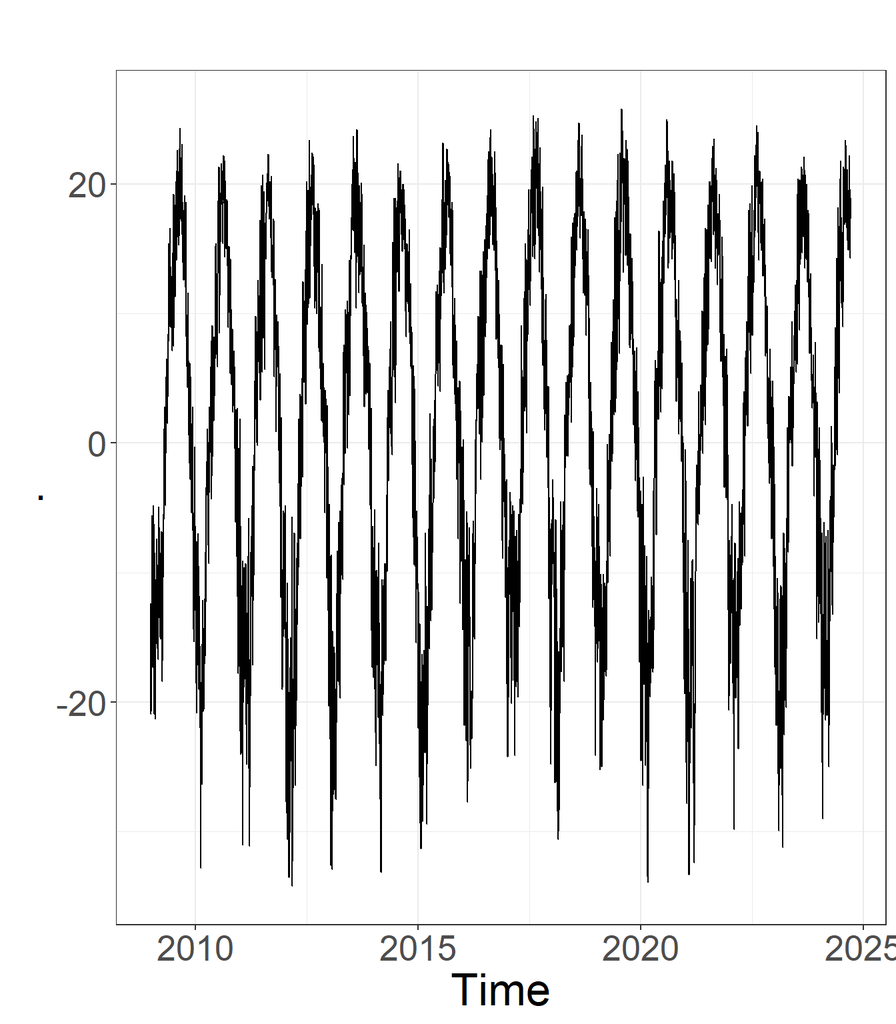

```r
brain_data %>%
  pull(Temp_mean) %>% ts(start = 2009, frequency = 365) %>%
  autoplot() + theme_custom
```

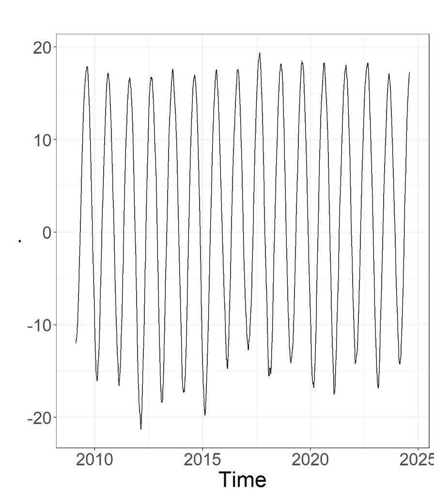

```r
brain_data %>%
  pull(Temp_mean) %>% ts(start = 2009, frequency = 365) %>%
  ma(90) %>% autoplot() + theme_custom
```

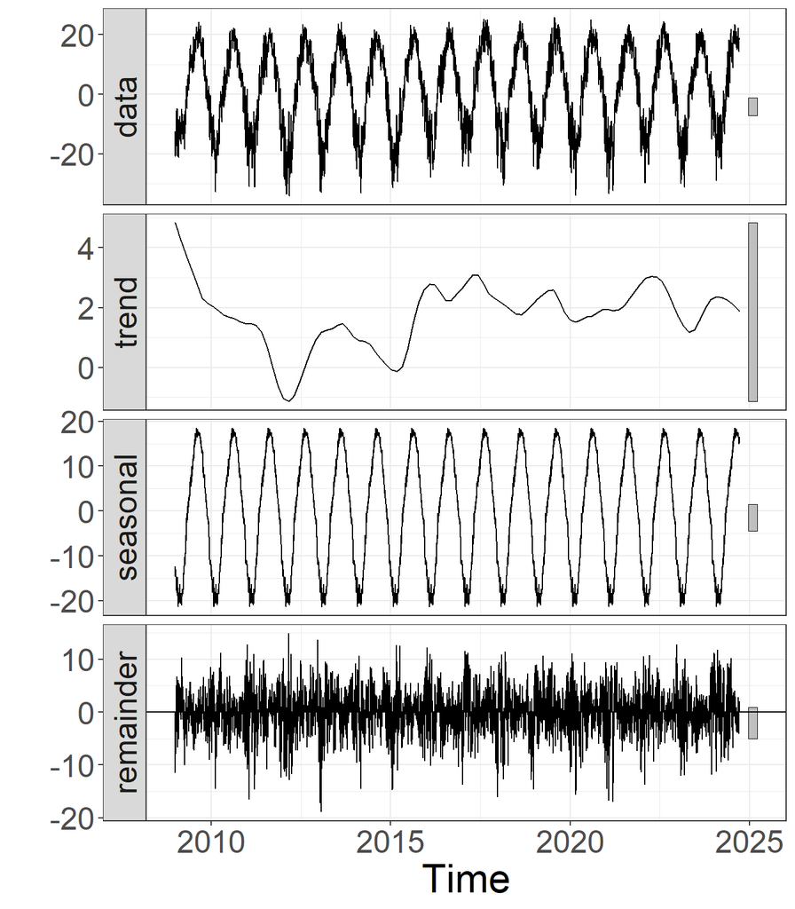

```r
brain_data %>%
  pull(Temp_mean) %>% ts(start = 2009, frequency = 365) %>%
  stl(s.window = "periodic") %>% autoplot() +
  theme_custom
```

Декомпозиция позволяет выявить тренды и сезонную цикличность:

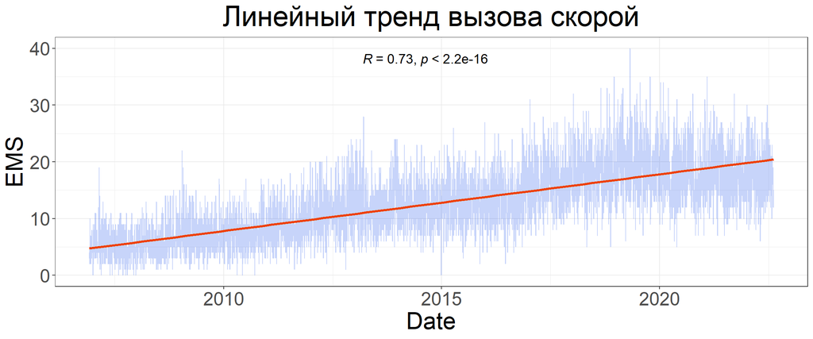

```r
##Линейный тренд EMS
brain_data %>%
  # filter(Date %within% interval(ymd("2009-01-01"), ymd("2019-12-31"))) %>%
  ggplot(aes(Date, EMS))+
  geom_line(alpha = 0.3, colour = "royalblue2")+
  geom_smooth(method = "lm", se = FALSE, colour = "orangered2", size = 1.2) +
  stat_cor(method = "pearson", label.x.npc = 0.4, label.y.npc = "top", size = 5)+
  theme_custom + ggtitle("Линейный тренд вызова скорой")
```

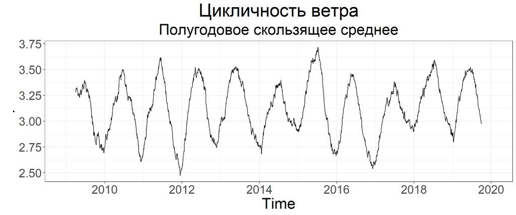

```r
##Сезонные тренды по температуре, ветру, осадкам
brain_data %>%
  filter(Date %within% interval(ymd("2009-01-01"), ymd("2019-12-31"))) %>%
  pull(Wind) %>% ts(start = 2009, frequency = 365) %>%
  ma(183) %>%
  autoplot() + theme_custom + ggtitle("Цикличность ветра",  subtitle = "Полугодовое скользящее среднее")
```

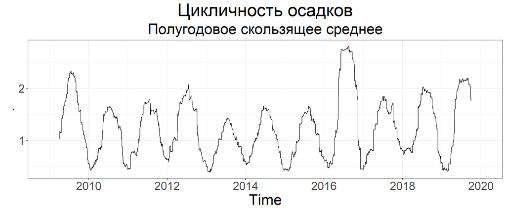

```r
brain_data %>%
  filter(Date %within% interval(ymd("2009-01-01"), ymd("2019-12-31"))) %>%
  pull(H2O) %>% ts(start = 2009, frequency = 365) %>%
  ma(183) %>%
  autoplot() + theme_custom + ggtitle("Цикличность осадков", subtitle = "Полугодовое скользящее среднее")
```

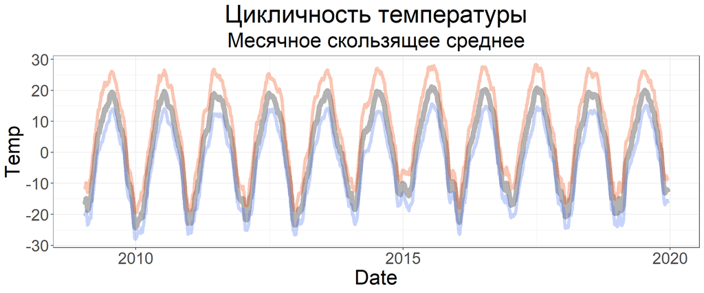

```r
brain_data %>%
  filter(Date %within% interval(ymd("2009-01-01"), ymd("2019-12-31"))) %>%
  ggplot(aes(x = Date))+
  geom_line(aes(y = Temp_mean %>% ma(30)), alpha = 0.3, colour = "black", size = 3)+
  geom_line(aes(y = Temp_min %>% ma(30)), alpha = 0.3, colour = "royalblue2", size = 2)+
  geom_line(aes(y = Temp_max %>% ma(30)), alpha = 0.3, colour = "orangered2", size = 2)+
  scale_y_continuous(name = "Temp")+
  theme_custom + ggtitle("Цикличность температуры", subtitle = "Месячное скользящее среднее")
```

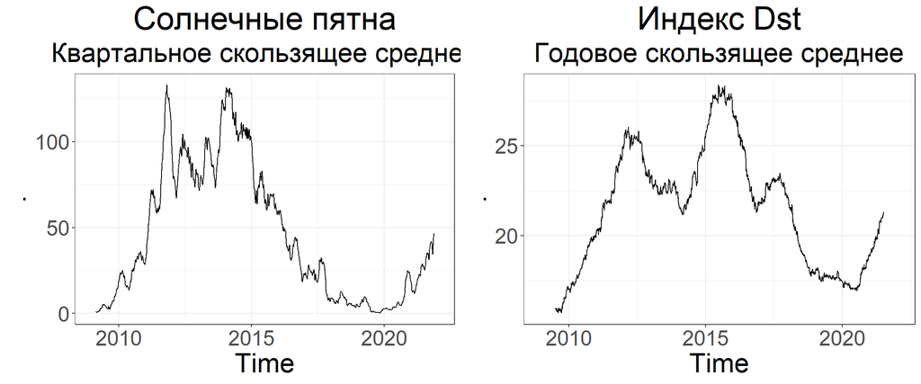

```r
# Сложности с индексом Dst
ggarrange(

  brain_data %>%
  mutate(Dst_var = Dst_max - Dst_min) %>%
  filter(Date %within% interval(ymd("2009-01-01"), ymd("2021-12-31"))) %>%
  pull(Sunspots) %>% ts(start = 2009, frequency = 365) %>%
  ma(90) %>%
  autoplot() + theme_custom + ggtitle("Солнечные пятна", subtitle = "Квартальное скользящее среднее"),

  brain_data %>%
  mutate(Dst_var = Dst_max - Dst_min) %>%
  filter(Date %within% interval(ymd("2009-01-01"), ymd("2021-12-31"))) %>%
  pull(Dst_var) %>% ts(start = 2009, frequency = 365) %>%
  ma(365) %>%
  autoplot() + theme_custom + ggtitle("Индекс Dst", subtitle = "Годовое скользящее среднее")

  )
```

- Для данных по вызову скорой наблюдается линейный тренд во времени. Для поиска связи вызовов и солнечной активности желательно внести поправку на это.
- Климатические данные (температура, осадки и ветер) имеют четкую цикличность
- Индекс Dst_mean не имеет четких трендов и циклов. Индекс Dst_var (амплитуда колебаний индекса Dst за день) при сглаживании данных сопоставим по тренду с количеством солнечных пятен.

# Установление связи

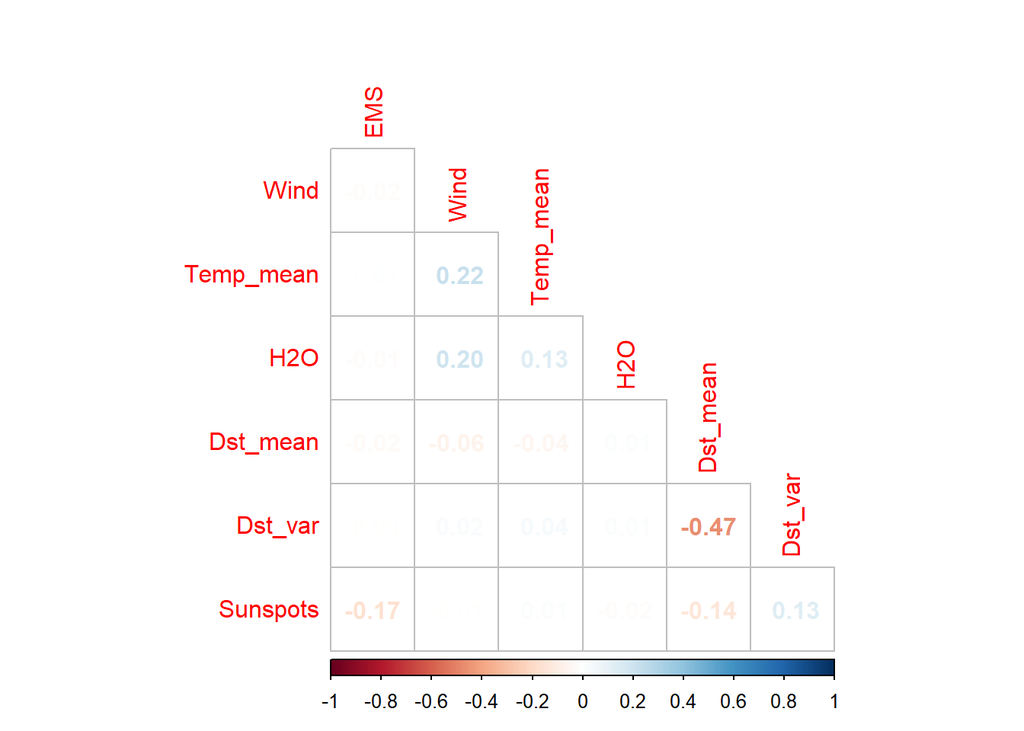

```r
cor_data2 <- brain_data %>%
  filter(Date %within% interval(ymd("2009-01-01"), ymd("2019-12-31"))) %>%
  transmute(EMS, Wind, Temp_mean, H2O, Dst_mean,
            Dst_var = Dst_max - Dst_min, Sunspots ) %>%
 cor(use = "pairwise.complete.obs")

corrplot(cor_data2, method = 'number', type = 'lower', diag = FALSE)
```

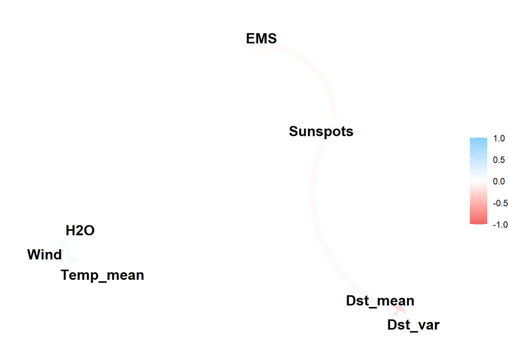

```r
network_plot(cor_data2, min_cor = 0.1)
```

Оставив только период равный 24ому циклу солнечной активности и отбросив скоррелированные переменные, можно заметить наличие связи количества солнечных пятен с суточной амплитудой индекса Dst, а также количеством вызовов скорой помощи. **Однако, данные по индексу Dst и количеству вызовов скорой помощи требуют дальнейшей проработки.**

# Обновление данных

```r
# Индекс Dst на каждый час
WDC_Kyoto_Dst <- read_fwf("../data/raw/WDC_Kyoto.dat",
                          fwf_widths( c(3, 2, 2, 1, 2, 2, 1, 1, 2, 4, rep(4, 24), 4) ),
                          show_col_types = FALSE) %>%
  transmute(
    Date = as.Date(paste0(X9,X2,"-",X3,"-",X5)),
    across(X11:X34) %>%  set_names(paste0("H_", seq(1, 24) ))
    ) %>%
  filter(Date %within% interval(ymd("2009-01-01"), ymd("2019-12-31")))


# Dst через PCA
scaled_Dst <- WDC_Kyoto_Dst %>% select(!Date) %>% scale()
Dst_pca <- prcomp(scaled_Dst)

summary(Dst_pca)
```

```
## Importance of components:
##                           PC1    PC2     PC3    PC4     PC5     PC6     PC7
## Standard deviation     4.3064 1.6502 1.05694 0.7200 0.55602 0.43468 0.37814
## Proportion of Variance 0.7727 0.1135 0.04655 0.0216 0.01288 0.00787 0.00596
## Cumulative Proportion  0.7727 0.8862 0.93272 0.9543 0.96720 0.97507 0.98103
##                            PC8     PC9    PC10    PC11    PC12    PC13   PC14
## Standard deviation     0.33254 0.28839 0.24351 0.20636 0.18116 0.16050 0.1389
## Proportion of Variance 0.00461 0.00347 0.00247 0.00177 0.00137 0.00107 0.0008
## Cumulative Proportion  0.98564 0.98911 0.99158 0.99335 0.99472 0.99579 0.9966
##                           PC15    PC16    PC17    PC18    PC19    PC20    PC21
## Standard deviation     0.12334 0.11191 0.10280 0.09152 0.08833 0.08214 0.07621
## Proportion of Variance 0.00063 0.00052 0.00044 0.00035 0.00033 0.00028 0.00024
## Cumulative Proportion  0.99723 0.99775 0.99819 0.99854 0.99887 0.99915 0.99939
##                           PC22    PC23    PC24
## Standard deviation     0.07162 0.07092 0.06703
## Proportion of Variance 0.00021 0.00021 0.00019
## Cumulative Proportion  0.99960 0.99981 1.00000
```

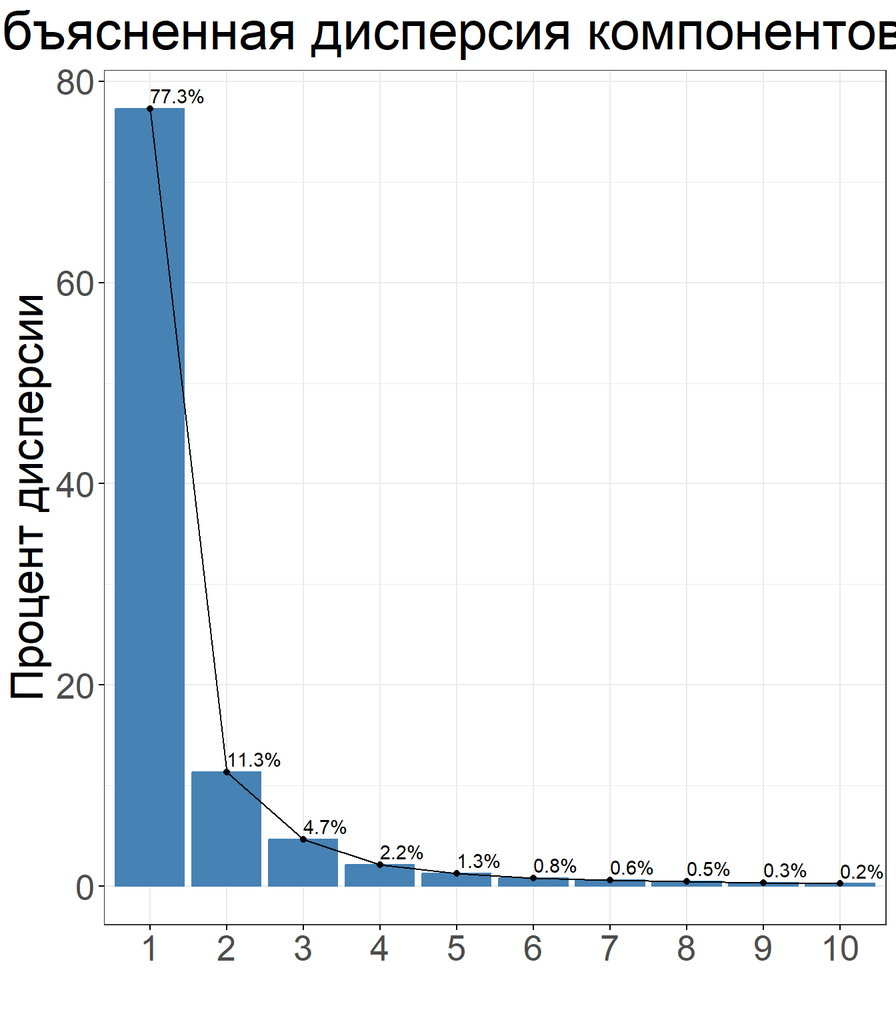

```r
fviz_eig(Dst_pca, addlabels = T,
         xlab = "", ylab = "Процент дисперсии",
         ggtheme = theme_custom,
         main = "Объясненная дисперсия компонентов PCA")
```

```r
# Обновление датасета
brain_data2 <- brain_data %>%
  filter(Date %within% interval(ymd("2009-01-01"), ymd("2019-12-31"))) %>%
  transmute(Date, Month = as.factor(month(Date)), Year = as.factor(year(Date)),
            EMS, Wind, Temp_mean, H2O, Sunspots, Sud_Imp, Sud_Storm,
            Dst_mean, Dst_var = Dst_max - Dst_min, Dst_group = factor(case_when(
              Dst_min < -150 ~ "level_5", Dst_min < -100 ~ "level_4",
              Dst_min < -50 ~ "level_3",  Dst_min < -20 ~ "level_2",
              TRUE ~ "level_1"),
              levels = c("level_1", "level_2", "level_3", "level_4", "level_5"),
              ordered = TRUE)
            ) %>%
  bind_cols( as.tibble(Dst_pca$x) %>% select(PC1, PC2) )
##Локальное храненение данных
write_csv(brain_data2, "../data/raw/brain_data2.csv")
```

# Визуализация ассоциаций

[figure not shown]

```r
#EMS/Sunspots сезонность

ggarrange(
brain_data2 %>%
  group_by(Year, Month) %>%
  summarise(EMS_month = sum(EMS, na.rm = TRUE), .groups = "drop") %>%
  ggplot(aes(x = Month, y = Year, fill = EMS_month)) +
  geom_tile(colour = "black") +
  scale_fill_gradient(low = "green", high = "red") +
  theme_custom,

brain_data2 %>%
  group_by(Year, Month) %>%
  summarise(Sunspots_month = sum(Sunspots, na.rm = TRUE), .groups = "drop") %>%
  ggplot(aes(x = Month, y = Year, fill = Sunspots_month)) +
  geom_tile(colour = "black") +
  scale_fill_gradient(low = "green", high = "red") +
  theme_custom
)
```

```r
#Dst ~ Sunspots
brain_data2 %>% group_by(Dst_group) %>% count()
```

```
## # A tibble: 5 × 2
## # Groups:   Dst_group [5]
##   Dst_group     n
##   <ord>     <int>
## 1 level_1    2379
## 2 level_2    1328
## 3 level_3     275
## 4 level_4      29
## 5 level_5       6
```

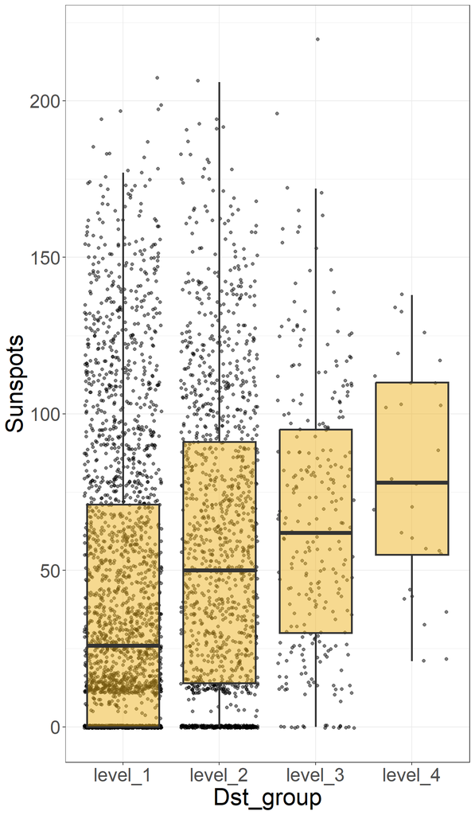

```r
brain_data2 %>%
  filter(Dst_group != "level_5") %>%
  ggplot(aes(Dst_group, Sunspots))+
  geom_jitter(alpha = 0.5)+
  geom_boxplot(alpha = 0.5, outliers = FALSE, fill = "goldenrod2", linewidth = 1)+
  theme_custom
```

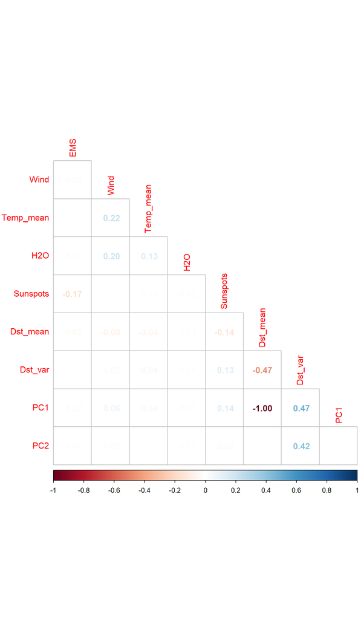

```r
#Корреляция
cor_data3 <- brain_data2 %>%
  select(where(is.numeric)) %>%
  cor(use = "pairwise.complete.obs")

corrplot(cor_data3, method = 'number', type = 'lower', diag = FALSE)
```

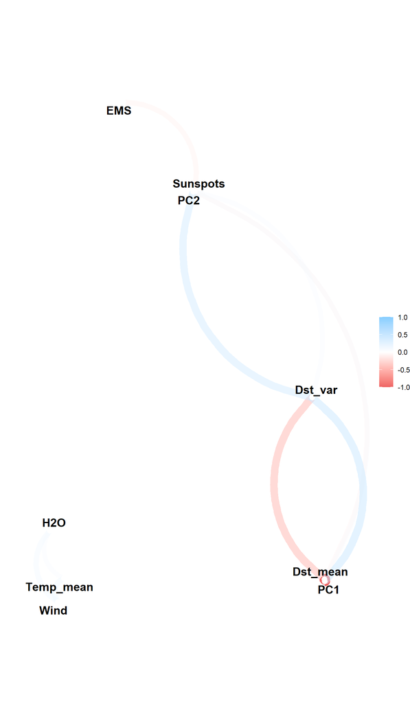

```r
network_plot(cor_data3, min_cor = 0.1)
```